# Text Based Data

## Data Types

```r
x <- "Rodney"
y <- 'Dyer'
```

You could use either single or double quotes to define a character type *de novo*—both work just fine. Having two of them is really helpful when you want to use one of the quote symbols inside the data.

```r
z <- 'Bob Marley once said, "It is a foolish dog that barks at a passing bird"'
z
```

```
[1] "Bob Marley once said, \"It is a foolish dog that barks at a passing bird\""
```

But notice that when you print it out to the terminal (or in the output to your Quarto chunck), it uses the `backslash-double quote` format. It also show up if you use `print`

```r
print(z)
```

```
[1] "Bob Marley once said, \"It is a foolish dog that barks at a passing bird\""
```

But not when you `cat` it:

```r
cat(z)
```

```
Bob Marley once said, "It is a foolish dog that barks at a passing bird"
```

This is called *escaping* a special character. And it is a valid way to embed a quoting character into a sequence.

```r
w <- "\"Learning R is Fun,\" said Rodney."
cat(w)
```

```
"Learning R is Fun," said Rodney.
```

There are other special characters that you will run across such as:

- The `Tab` character, `\t`
- The `New Line` character `\n`
- The `Return` character `\r`. This is becoming obsolete, in the “olden days” it was used with new line when we were making a transition from the manual typewriter where if you think about the action of using a typewriter, you need to advance a line AND return the carrage—the part that makes the letters on the paper—to the beginning of the line. That is why you sometimes see CR for on the return key. Windows used this convention and you may run across it still form peole who use that platform as `\r\n`. Mostly it is just yet another annoyance from some Windows software.

To see more, visit `?"'"` in R.

## The `stringr` Library

Another joy from the `tidyverse` folks is the `stringr` library that has made things a bit easier in handling string data. As usual, there is a cheatsheet linked in the assets on this topic.

```r
library( tidyverse )
```

## The ’Verbs”

When dealing with text, there are some basic `verbs` that we should recognize as fundamental actions that you’ll apply across a wide variety of situations. For text data, these include:

- `Creating` new/composite text.
- `Finding` content inside a string.
- `Deleting` content within a string
- `Replacing` content in a string with some new character value.
- `Manipulating` content in a string.

### Creating

We’ve already seen how to create a single string, here is how we can smush (yes that is a technical term) together several kinds of data.

```r
paste( "This","is","fun")
```

```
[1] "This is fun"
```

You can also mix-and-match different data types, as long as they can be coerced into a string type (which all data types can).

```r
num <- 42
paste("It is", TRUE, "that my favorite number is", num, ".")
```

```
[1] "It is TRUE that my favorite number is 42 ."
```

When we work with character data, we need to realize that from the context of indexing, such as when we use a vector or `data.frame`, the sequence of characters is all one object.

```r
length(z)
```

```
[1] 1
```

Even if it is made up of several characters. If we are interested subsequences within the string, we need to ask more specifically about the string length, not the variable length.

```r
str_length( z )
```

```
[1] 72
```

There are times when we need to paste more than a couple of individual items together.

```r
a <- 1:10
paste( a )
```

```
 [1] "1"  "2"  "3"  "4"  "5"  "6"  "7"  "8"  "9"  "10"
```

```r
paste( a, sep=", ")
```

```
 [1] "1"  "2"  "3"  "4"  "5"  "6"  "7"  "8"  "9"  "10"
```

```r
paste( a, collapse=", ")
```

```
[1] "1, 2, 3, 4, 5, 6, 7, 8, 9, 10"
```

as separate columns

```r
b <- LETTERS[1:10]
c <- rnorm(10,12, 1)
paste( a,b,c, sep = "-" )
```

```
 [1] "1-A-11.8160548618631"  "2-B-13.1705259435518"  "3-C-12.458060669323"
 [4] "4-D-13.6021798653777"  "5-E-11.2356291032712"  "6-F-12.39675444697"
 [7] "7-G-12.7800926251443"  "8-H-11.6167561629943"  "9-I-12.0467595739421"
[10] "10-J-12.8957269181935"
```

A `stringr` version is also available—with fewer keystrokes!

```r
str_c( a, collapse=", " )
```

```
[1] "1, 2, 3, 4, 5, 6, 7, 8, 9, 10"
```

and

```r
str_c( a,b,c)
```

```
 [1] "1A11.8160548618631"  "2B13.1705259435518"  "3C12.458060669323"
 [4] "4D13.6021798653777"  "5E11.2356291032712"  "6F12.39675444697"
 [7] "7G12.7800926251443"  "8H11.6167561629943"  "9I12.0467595739421"
[10] "10J12.8957269181935"
```

```r
str_c( a,b,c, sep="-")
```

```
 [1] "1-A-11.8160548618631"  "2-B-13.1705259435518"  "3-C-12.458060669323"
 [4] "4-D-13.6021798653777"  "5-E-11.2356291032712"  "6-F-12.39675444697"
 [7] "7-G-12.7800926251443"  "8-H-11.6167561629943"  "9-I-12.0467595739421"
[10] "10-J-12.8957269181935"
```

### Finding

Finding text may be done in a few ways.

```r
cat(z)
```

```
Bob Marley once said, "It is a foolish dog that barks at a passing bird"
```

We can ask if:

1. A particular sequence of characters exist in the string (`TRUE/FALSE`).

```r
str_detect(z, "Marley")
```

```
[1] TRUE
```

```r
str_detect(z, "marley") # case sensitive
```

```
[1] FALSE
```

2. We can ask for the number of times a sequences shows up in a string.

```r
str_count(z, "a")
```

```
[1] 8
```

3. We can ask where the first occurance of a subsequence of characters starts at:

```r
str_locate( z, "dog")
```

```
     start end
[1,]    40  42
```

4. We can find all occurences of a substring.

```r
str_locate_all( z, "a")
```

```
[[1]]
     start end
[1,]     6   6
[2,]    18  18
[3,]    30  30
[4,]    46  46
[5,]    50  50
[6,]    55  55
[7,]    58  58
[8,]    61  61
```

5. If we know the location of a substring, you can extract it. Here I use the negative for the second index, which is treated as “second from the end” of the string.

```r
str_sub(z, 24, -2)
```

```
[1] "It is a foolish dog that barks at a passing bird"
```

6. If we have several character objects in a vector, we can find the subset that contains a specific sequence.

```r
character_vec <- c(w,x,y,z)
character_vec
```

```
[1] "\"Learning R is Fun,\" said Rodney."
[2] "Rodney"
[3] "Dyer"
[4] "Bob Marley once said, \"It is a foolish dog that barks at a passing bird\""
```

```r
str_detect( character_vec, "r")
```

```
[1]  TRUE FALSE  TRUE  TRUE
```

However, it is case sensitive

```r
str_detect( character_vec, "R")
```

```
[1]  TRUE  TRUE FALSE FALSE
```

### Deleting

This is an easy one, if we want to remove one (the first occurence of) an item,

```r
str_remove(z,"dog")
```

```
[1] "Bob Marley once said, \"It is a foolish  that barks at a passing bird\""
```

Or all of them.

```r
str_remove_all(z, "a")
```

```
[1] "Bob Mrley once sid, \"It is  foolish dog tht brks t  pssing bird\""
```

We can also remove compoennts by truncation

```r
str_trunc( character_vec , 20)
```

```
[1] "\"Learning R is Fu..." "Rodney"                "Dyer"
[4] "Bob Marley once s..."
```

### Replacing

There are times when we are wanting to take some component within a string and replace it with another one—independent of the location of the item to be replaced within the string.

```r
cat( str_replace(z, "Bob Marley", "Rodney") )
```

```
Rodney once said, "It is a foolish dog that barks at a passing bird"
```

If we do know the location (character location) and size (`str_length`) of what we are replacing, then we can use those numerical values direction.

```r
str_sub(z, 1, 10)
```

```
[1] "Bob Marley"
```

### Manipulating

1. Making the string all lower case.

```r
str_to_lower(z)
```

```
[1] "bob marley once said, \"it is a foolish dog that barks at a passing bird\""
```

2. Making it all uppercase.

```r
str_to_upper(z)
```

```
[1] "BOB MARLEY ONCE SAID, \"IT IS A FOOLISH DOG THAT BARKS AT A PASSING BIRD\""
```

3. Creating `Title Case` text.

```r
str_to_title(z)
```

```
[1] "Bob Marley Once Said, \"It Is A Foolish Dog That Barks At A Passing Bird\""
```

4. Capitalizing it as if it were a sentence.

```r
str_to_sentence( "this is getting a bit old, isn't it?")
```

```
[1] "This is getting a bit old, isn't it?"
```

```r
tmp <- str_to_sentence("rodney exclaimed, \"but it doesn't know about internal quoted sentence fragments!\" and then sat down.")
cat(tmp)
```

```
Rodney exclaimed, "but it doesn't know about internal quoted sentence fragments!" And then sat down.
```

# A Practical Example: Text Parsing

**Practical Problem**

You are working on curriculum at VCU and need to generate a `data.frame` of courses that have a columns for `Program`, `Course Number`, `Course Title`, and `Credit Hours`.

The raw data you have is the university bulletin.

## Regular Expressions

A regular expression, or *regex* is a concise language used for detecting and describing patterns found in language. An entire course could be taught on the use of *regex* but here we’ll only spend enough time on it so that you know some kind of magic exists in the universe and can explore it if you need to in the future.

For this example, I’m going to use some text data that I have been playing with regarding curriculum development.

```r
library( readr )
url <- "https://raw.githubusercontent.com/DyerlabTeaching/Textual-Data/refs/heads/main/data/ENVSclasses.txt?token=GHSAT0AAAAAACWO27UIA46V72P7DBZEP5EKZYZFFXQ"
read_lines( url ) -> envs
```

This goes out and grabs the data, and reads it in as a vector of type character.

```r
class( envs )
```

```
[1] "character"
```

If we take a look at it, we can see these are the listings for the undergraduate courses in Environmental Studies at [VCU](https://vcu.edu).

```r
head(envs,17)
```

```
 [1] "ENVS 101. Introduction to Environmental Studies I. 3 Hours."
 [2] "Semester course; 3 lecture hours. 3 credits. Enrollment is restricted to"
 [3] "environmental studies majors. Study of contemporary issues related to"
 [4] "environmental studies including sustainability, biological conservation,"
 [5] "global change and an overview of the core earth systems."
 [6] "ENVS 102. Introduction to Environmental Studies II. 3 Hours."
 [7] "Semester course; 3 lecture hours. 3 credits. Prerequisite: ENVS 101 or"
 [8] "permission of instructor. Enrollment is restricted to environmental studies"
 [9] "majors. Studies of contemporary issues related to government policy and"
[10] "environmental issues at local to international scales."
[11] "886 Undergraduate courses"
[12] "ENVS 105. Physical Geology. 3 Hours."
[13] "Semester course; 3 lecture hours. 3 credits. A descriptive approach to"
[14] "physical geology dealing with the history and structure of the earth,"
[15] "catastrophic events and geology as it relates to the contemporary"
[16] "environment. An optional laboratory, ENVZ 105, may be taken with this"
[17] "course."
```

There are a couple of things to notice:

1. The lines are short and the entry for each course is spread across several lines.
2. Each course has a 4-letter code, a 3-digit number, a title, and then ends with the number of hours for the class.
3. There are five lines necessary to describe ENVS 101 but six for ENVS 105.
4. Line 11 appears to be a page number and page heading and not part of any course description.

Let’s say we wanted to extract some information about the course number, name, and number of hours from these data. This subset of data only has 262 line of text but if we were looking at all the courses at VCU, we would be faced with 25,945 lines of text! It could be done by hand but… that does not scale too well and I’ve got a lot better things to do than spend a year working on this simple task.

### Matching

Let’s start by matching. Let’s look at what we did above and see if there are any tools we can use.

We do know that `str_detect()` will give us a `TRUE/FALSE` for any match. Let’s try that and take a look at the results.

```r
idx <- str_detect(envs,"ENVS")
head( envs[idx] )
```

```
[1] "ENVS 101. Introduction to Environmental Studies I. 3 Hours."
[2] "ENVS 102. Introduction to Environmental Studies II. 3 Hours."
[3] "Semester course; 3 lecture hours. 3 credits. Prerequisite: ENVS 101 or"
[4] "ENVS 105. Physical Geology. 3 Hours."
[5] "ENVS 201. Earth System Science. 3 Hours."
[6] "ENVS 222. Electronic Portfolios. 1 Hour."
```

OK, except that line 3 isn’t a title line, it just has an `ENVS` in it.

Moveover, it also assumes that we are going to only be using `ENVS` but if we look at the end of the data set, we see that the lab courses in Environmental Studies are encoded as `ENVZ` and these will be totally ignored. Moreover, we would need to know, *a priori*, what all the program codes were before we started if we were going to take this approach.

```r
tail( envs )
```

```
[1] "Laboratory exercises coordinated with ENVS 335 lectures."
[2] "ENVZ 401. Meteorology and Climatology Laboratory. 1 Hour."
[3] "Semester course; 3 laboratory hours. 1 credit. Pre- or corequisite:"
[4] "ENVS 401. A series of laboratory and field experiments designed to"
[5] "quantify the elements of weather and climate and to interpret their local"
[6] "temporal and spatial variations."
```

Using *regex* we can define a character **pattern** to look for. Let’s start by just taking the first line of text and using that to learn about pattern matching.

```r
envs101 <- envs[1]
envs101
```

```
[1] "ENVS 101. Introduction to Environmental Studies I. 3 Hours."
```

The `stringr` library has a helper function that allows us to see what parts of a string are being matched by a specific pattern. This function is `str_view()` and it colors and puts into angle brackets, the part that is matched.

So, looking for the characters `ENVS` looks like:

```r
str_view(envs101,"ENVS")
```

```
[1] │ <ENVS> 101. Introduction to Environmental Studies I. 3 Hours.
```

and looking for `101` yields.

```r
str_view( envs101, "101")
```

```
[1] │ ENVS <101>. Introduction to Environmental Studies I. 3 Hours.
```

If ther is no match, nothing is returned:

```r
str_view( envs101, "Rodney")
```

and if many things are matched, it will highlight each of them.

```r
str_view( envs101, "o")
```

```
[1] │ ENVS 101. Intr<o>ducti<o>n t<o> Envir<o>nmental Studies I. 3 H<o>urs.
```

So, let’s get more general and look for patterns. These patterns are encoded using square brackets.

1. Matching on any digit, which is defined as `[:digit:]`.

```r
str_view( envs101, "[:digit:]")
```

```
[1] │ ENVS <1><0><1>. Introduction to Environmental Studies I. <3> Hours.
```

```r
str_view( envs101, "[:alpha:]")
```

```
[1] │ <E><N><V><S> 101. <I><n><t><r><o><d><u><c><t><i><o><n> <t><o> <E><n><v><i><r><o><n><m><e><n><t><a><l> <S><t><u><d><i><e><s> <I>. 3 <H><o><u><r><s>.
```

3. Matching punctuation, `[:punct:]`

```r
str_view( envs101, "[:punct:]")
```

```
[1] │ ENVS 101<.> Introduction to Environmental Studies I<.> 3 Hours<.>
```

4. We can also specify the case of the punctuation.

```r
str_view( envs101, "[:lower:]")
```

```
[1] │ ENVS 101. I<n><t><r><o><d><u><c><t><i><o><n> <t><o> E<n><v><i><r><o><n><m><e><n><t><a><l> S<t><u><d><i><e><s> I. 3 H<o><u><r><s>.
```

```r
str_view( envs101, "[:upper:]")
```

```
[1] │ <E><N><V><S> 101. <I>ntroduction to <E>nvironmental <S>tudies <I>. 3 <H>ours.
```

5. Or even spaces

```r
str_view( envs101, "[:space:]")
```

```
[1] │ ENVS< >101.< >Introduction< >to< >Environmental< >Studies< >I.< >3< >Hours.
```

### Combining Matches

That is helpful in some cases. But now we can start combining these things.

1. Let’s mix a pattern and a fixed set of characters.

```r
str_view( envs101, "[:digit:] Hours")
```

```
[1] │ ENVS 101. Introduction to Environmental Studies I. <3 Hours>.
```

2. How about multiple patterns.

```r
str_view( envs101, "[:upper:][:space:][:digit:]")
```

```
[1] │ ENV<S 1>01. Introduction to Environmental Studies I. 3 Hours.
```

3. Or multiples of the same pattern. To have the exact number of items, use a single number enclosed in curly brackets right after ther pattern. Here we are matching 4-upper case digits.

```r
str_view(envs101, "[:upper:]{4}")
```

```
[1] │ <ENVS> 101. Introduction to Environmental Studies I. 3 Hours.
```

We could also match those followed by a space and three numbers

```r
str_view( envs101, "[:upper:]{4}[:space:][:digit:]{3}")
```

```
[1] │ <ENVS 101>. Introduction to Environmental Studies I. 3 Hours.
```

4. We can generalize this a bit by asking for “zero or one” or “zero or more”—IMHO this is a terrible thing to match as a single thing.

```r
str_view( envs101, "[:punct:]?")
```

```
[1] │ <>E<>N<>V<>S<> <>1<>0<>1<.><> <>I<>n<>t<>r<>o<>d<>u<>c<>t<>i<>o<>n<> <>t<>o<> <>E<>n<>v<>i<>r<>o<>n<>m<>e<>n<>t<>a<>l<> <>S<>t<>u<>d<>i<>e<>s<> <>I<.><> <>3<> <>H<>o<>u<>r<>s<.><>
```

```r
str_view( envs101, "[:punct:]*")
```

```
[1] │ <>E<>N<>V<>S<> <>1<>0<>1<.><> <>I<>n<>t<>r<>o<>d<>u<>c<>t<>i<>o<>n<> <>t<>o<> <>E<>n<>v<>i<>r<>o<>n<>m<>e<>n<>t<>a<>l<> <>S<>t<>u<>d<>i<>e<>s<> <>I<.><> <>3<> <>H<>o<>u<>r<>s<.><>
```

But for our purposes, we can ask for “one or more” by appending a plus sign.

```r
str_view( envs101, "[:digit:]+")
```

```
[1] │ ENVS <101>. Introduction to Environmental Studies I. <3> Hours.
```

or match to digits, punctuation, or letters (one or more) using the shorthand `.+` notation. It is the period that matches anything and the plus that does one or more of them.

```r
str_view( envs101, ".+")
```

```
[1] │ <ENVS 101. Introduction to Environmental Studies I. 3 Hours.>
```

This becomes helpful a bit later when we are trying to anchor the course designation (e.g., ENVS 101) at the start, ONE OR MORE THING IN THE MIDDLE, and then the end of the line with the number of hours (e.g., 3 Hours.)

### Positional Matching

Where the items is in the string may be of importance to us. For example, consider another line in the data that specifies ENVS101 as a prerequisite. It does not come from a line of text that is the title of the course, it just also happens to match the 4 uppercase letters, space, and three digits pattern.

```r
str_view( envs[37], "[:upper:]{4}[:space:][:digit:]{3}")
```

```
[1] │ Semester course; 2 lecture hours. 2 credits. Prerequisites: <ENVS 101>
```

This is where the position in the line may be of interest.

1. To match things that occur at the beginning of the string, we prepend the pattern with the carat symbol.

```r
str_view( envs101, "^[:upper:]{4}[:space:][:digit:]{3}")
```

```
[1] │ <ENVS 101>. Introduction to Environmental Studies I. 3 Hours.
```

This matches our first line but not a line where this pattern does not occur in the beginning of the string.

```r
str_view( envs[37], "^[:upper:]{4}[:space:][:digit:]{3}")
```

2. For the end of the string, we use the dollar sign to anchor it to the end.

```r
str_view( envs[37], "[:upper:]{4}[:space:][:digit:]{3}$")
```

```
[1] │ Semester course; 2 lecture hours. 2 credits. Prerequisites: <ENVS 101>
```

which is not in the envs101 string

```r
str_view( envs101, "[:upper:]{4}[:space:][:digit:]{3}$")
```

### Putting it Together

So, now let’s pull this all together and see if we can match: 1. The course designation at the start of the line. 2. The title 3. The end of the line with the number of hours.

```r
str_view( envs101, "^[:upper:]{4} [:digit:]{3}.*[:digit:] Hours.$")
```

```
[1] │ <ENVS 101. Introduction to Environmental Studies I. 3 Hours.>
```

So, there is one little extension—and this a common theme we’ve run across—and that has to do with the fact that programmers are a bit lazy. You can subsititue, the square-bracket-colon-word-colon-square-bracket for the following:

- `[0-9]` is shorthand for `[:digits:]`.
- `[a-z]` is shorthand for `[:lower:]`.
- `[A-Z]` is shorthand for `[:upper:]`.

Which means that we can go from

```r
pattern <- "^[:upper:]{4} [:digit:]{3}.*[:digit:] Hours.$"
```

to this

```r
pattern <- "^[A-Z]{4} [0-9]{3}.+[0-9] Hours.$"
```

as our seach pattern.

```r
str_view( envs101, pattern )
```

```
[1] │ <ENVS 101. Introduction to Environmental Studies I. 3 Hours.>
```

Instead of asking a single line, we need to apply this expressions to each line in the data an return the ones that match. For this, we can use `grepl`, which returns a `TRUE/FALSE` on matching. The tricky thing here is that the pattern comes first and the vector second (reverse from what we’ve been using.)

So for our data, we see

```r
grepl(pattern, envs )
```

```
  [1]  TRUE FALSE FALSE FALSE FALSE  TRUE FALSE FALSE FALSE FALSE FALSE  TRUE
 [13] FALSE FALSE FALSE FALSE FALSE  TRUE FALSE FALSE FALSE FALSE FALSE FALSE
 [25] FALSE FALSE FALSE FALSE  TRUE FALSE FALSE FALSE FALSE FALSE FALSE  TRUE
 [37] FALSE FALSE FALSE FALSE FALSE FALSE FALSE FALSE FALSE FALSE  TRUE FALSE
 [49] FALSE FALSE FALSE  TRUE FALSE FALSE FALSE FALSE  TRUE FALSE FALSE FALSE
 [61] FALSE FALSE FALSE  TRUE FALSE FALSE FALSE FALSE FALSE FALSE FALSE  TRUE
 [73] FALSE FALSE FALSE FALSE FALSE FALSE FALSE FALSE FALSE FALSE FALSE FALSE
 [85] FALSE FALSE  TRUE FALSE FALSE FALSE FALSE FALSE  TRUE FALSE FALSE FALSE
 [97] FALSE FALSE FALSE FALSE  TRUE FALSE FALSE FALSE  TRUE FALSE FALSE FALSE
[109] FALSE FALSE FALSE FALSE  TRUE FALSE FALSE FALSE FALSE FALSE  TRUE FALSE
[121] FALSE FALSE FALSE FALSE FALSE FALSE  TRUE FALSE FALSE FALSE FALSE FALSE
[133] FALSE  TRUE FALSE FALSE FALSE FALSE  TRUE FALSE FALSE FALSE FALSE FALSE
[145] FALSE  TRUE FALSE FALSE FALSE FALSE FALSE  TRUE FALSE FALSE FALSE FALSE
[157] FALSE FALSE  TRUE FALSE FALSE FALSE FALSE  TRUE FALSE FALSE FALSE FALSE
[169] FALSE  TRUE FALSE FALSE FALSE FALSE FALSE FALSE  TRUE FALSE FALSE FALSE
[181] FALSE FALSE FALSE FALSE FALSE FALSE FALSE  TRUE FALSE FALSE FALSE FALSE
[193] FALSE FALSE FALSE FALSE  TRUE FALSE FALSE FALSE FALSE FALSE FALSE FALSE
[205] FALSE FALSE FALSE FALSE FALSE  TRUE FALSE FALSE FALSE FALSE FALSE FALSE
[217] FALSE FALSE  TRUE FALSE FALSE FALSE FALSE FALSE FALSE FALSE  TRUE FALSE
[229] FALSE FALSE FALSE  TRUE FALSE FALSE FALSE FALSE  TRUE FALSE FALSE FALSE
[241]  TRUE FALSE FALSE FALSE FALSE FALSE FALSE FALSE FALSE FALSE FALSE FALSE
[253] FALSE FALSE FALSE FALSE FALSE FALSE FALSE FALSE FALSE FALSE
```

Which is great as we can use it for extracting the lines of the data that have our information. Let’s use the `grepl` as indices and grab the titles from `envs` using it.

```r
idx <- grepl( pattern, envs )
envs[idx] -> titles
titles
```

```
 [1] "ENVS 101. Introduction to Environmental Studies I. 3 Hours."
 [2] "ENVS 102. Introduction to Environmental Studies II. 3 Hours."
 [3] "ENVS 105. Physical Geology. 3 Hours."
 [4] "ENVS 201. Earth System Science. 3 Hours."
 [5] "ENVS 260. Outdoor Leadership. 3 Hours."
 [6] "ENVS 265. Paths to Environmental Leadership. 2 Hours."
 [7] "ENVS 291. Special Topics in Environmental Studies. 1-4 Hours."
 [8] "ENVS 300. Sustainable Societies: James River Basin. 3 Hours."
 [9] "ENVS 301. Introduction to Meteorology. 3 Hours."
[10] "ENVS 310. Introduction to Oceanography. 3 Hours."
[11] "ENVS 311. Politics of the Environment. 3 Hours."
[12] "ENVS 315. Energy and the Environment. 3 Hours."
[13] "ENVS 321. Cartography. 3 Hours."
[14] "ENVS 330. Environmental Pollution. 3 Hours."
[15] "ENVS 332. Environmental Management. 3 Hours."
```

[output cut: 19 more lines]

That looks pretty good! We are almost there.

```r
raw <- str_split(titles, pattern="\\.", simplify = TRUE)
dim(raw)
```

```
[1] 34  4
```

```r
head(raw)
```

```
     [,1]       [,2]                                        [,3]       [,4]
[1,] "ENVS 101" " Introduction to Environmental Studies I"  " 3 Hours" ""
[2,] "ENVS 102" " Introduction to Environmental Studies II" " 3 Hours" ""
[3,] "ENVS 105" " Physical Geology"                         " 3 Hours" ""
[4,] "ENVS 201" " Earth System Science"                     " 3 Hours" ""
[5,] "ENVS 260" " Outdoor Leadership"                       " 3 Hours" ""
[6,] "ENVS 265" " Paths to Environmental Leadership"        " 2 Hours" ""
```

OK, so now we can easily grab these columns and put them into a `data.frame`.

```r
program <- str_split( raw[,1], pattern=" ", simplify=TRUE)[,1]
program
```

```
 [1] "ENVS" "ENVS" "ENVS" "ENVS" "ENVS" "ENVS" "ENVS" "ENVS" "ENVS" "ENVS"
[11] "ENVS" "ENVS" "ENVS" "ENVS" "ENVS" "ENVS" "ENVS" "ENVS" "ENVS" "ENVS"
[21] "ENVS" "ENVS" "ENVS" "ENVS" "ENVS" "ENVS" "ENVS" "ENVS" "ENVS" "ENVS"
[31] "ENVS" "ENVS" "ENVS" "ENVS"
```

```r
code <- str_split( raw[,1], pattern=" ", simplify=TRUE)[,2]
code <- as.numeric( code )
code
```

```
 [1] 101 102 105 201 260 265 291 300 301 310 311 315 321 330 332 335 343 355 360
[20] 361 368 370 391 401 411 421 430 460 461 490 491 492 493 499
```

```r
title <- raw[,2]
title
```

```
 [1] " Introduction to Environmental Studies I"
 [2] " Introduction to Environmental Studies II"
 [3] " Physical Geology"
 [4] " Earth System Science"
 [5] " Outdoor Leadership"
 [6] " Paths to Environmental Leadership"
 [7] " Special Topics in Environmental Studies"
 [8] " Sustainable Societies: James River Basin"
 [9] " Introduction to Meteorology"
[10] " Introduction to Oceanography"
[11] " Politics of the Environment"
[12] " Energy and the Environment"
[13] " Cartography"
[14] " Environmental Pollution"
[15] " Environmental Management"
```

[output cut: 19 more lines]

```r
credits <- raw[,3]
credits <- str_replace(credits, "Hours", "")
credits <- str_trim( credits )
credits
```

```
 [1] "3"   "3"   "3"   "3"   "3"   "2"   "1-4" "3"   "3"   "3"   "3"   "3"
[13] "3"   "3"   "3"   "3"   "4"   "3"   "3"   "3"   "3"   "3"   "1-4" "3"
[25] "3"   "3"   "3"   "3"   "3"   "3"   "1-4" "1-3" "1-3" "0"
```

```r
data.frame( program, code, title, credits) -> df
summary(df)
```

```
   program               code          title             credits
 Length:34          Min.   :101.0   Length:34          Length:34
 Class :character   1st Qu.:303.2   Class :character   Class :character
 Mode  :character   Median :349.0   Mode  :character   Mode  :character
                    Mean   :346.4
                    3rd Qu.:418.5
                    Max.   :499.0
```

```r
head(df)
```

```
  program code                                     title credits
1    ENVS  101   Introduction to Environmental Studies I       3
2    ENVS  102  Introduction to Environmental Studies II       3
3    ENVS  105                          Physical Geology       3
4    ENVS  201                      Earth System Science       3
5    ENVS  260                        Outdoor Leadership       3
6    ENVS  265         Paths to Environmental Leadership       2
```

## Extra Credit

Let’s close by doing something fun. Let’s make a wordcloud of the titles from ENVS classes.

```r
str_split( title, " ")
```

```
[[1]]
[1] ""              "Introduction"  "to"            "Environmental"
[5] "Studies"       "I"

[[2]]
[1] ""              "Introduction"  "to"            "Environmental"
[5] "Studies"       "II"

[[3]]
[1] ""         "Physical" "Geology"

[[4]]
[1] ""        "Earth"   "System"  "Science"

[[5]]
[1] ""           "Outdoor"    "Leadership"

[[6]]
[1] ""              "Paths"         "to"            "Environmental"
[5] "Leadership"

[[7]]
[1] ""              "Special"       "Topics"        "in"
[5] "Environmental" "Studies"

[[8]]
[1] ""            "Sustainable" "Societies:"  "James"       "River"
[6] "Basin"

[[9]]
[1] ""             "Introduction" "to"           "Meteorology"

[[10]]
[1] ""             "Introduction" "to"           "Oceanography"

[[11]]
[1] ""            "Politics"    "of"          "the"         "Environment"

[[12]]
[1] ""            "Energy"      "and"         "the"         "Environment"
```

[output cut: 57 more lines]

```
[5] "Environmental" "Studies"

[[31]]
[1] ""              "Topics"        "in"            "Environmental"
[5] "Studies"

[[32]]
[1] ""            "Independent" "Study"

[[33]]
[1] ""              "Environmental" "Studies"       "Internship"

[[34]]
[1] ""              "Environmental" "Studies"       "Capstone"
[5] "Experience"
```

```r
str_split( title, " ", simplify=TRUE)
```

```
      [,1] [,2]            [,3]          [,4]            [,5]
 [1,] ""   "Introduction"  "to"          "Environmental" "Studies"
 [2,] ""   "Introduction"  "to"          "Environmental" "Studies"
 [3,] ""   "Physical"      "Geology"     ""              ""
 [4,] ""   "Earth"         "System"      "Science"       ""
 [5,] ""   "Outdoor"       "Leadership"  ""              ""
 [6,] ""   "Paths"         "to"          "Environmental" "Leadership"
 [7,] ""   "Special"       "Topics"      "in"            "Environmental"
 [8,] ""   "Sustainable"   "Societies:"  "James"         "River"
 [9,] ""   "Introduction"  "to"          "Meteorology"   ""
[10,] ""   "Introduction"  "to"          "Oceanography"  ""
[11,] ""   "Politics"      "of"          "the"           "Environment"
[12,] ""   "Energy"        "and"         "the"           "Environment"
[13,] ""   "Cartography"   ""            ""              ""
[14,] ""   "Environmental" "Pollution"   ""              ""
```

[output cut: 55 more lines]

```r
as.vector( str_split( title, " ", simplify=TRUE) ) -> words

words <- words[ str_length(words) > 0 ]

words <- sort( words )
words
```

```
  [1] "and"           "and"           "and"           "and"
  [5] "and"           "Applications"  "Basin"         "Building"
  [9] "Capstone"      "Cartography"   "Climatology"   "Conservation"
 [13] "Data"          "Data"          "Earth"         "Energy"
 [17] "Environment"   "Environment"   "Environmental" "Environmental"
 [21] "Environmental" "Environmental" "Environmental" "Environmental"
 [25] "Environmental" "Environmental" "Environmental" "Environmental"
 [29] "Environmental" "Environmental" "Environmental" "Event"
 [33] "Experience"    "Facilitation"  "First"         "Geology"
 [37] "Geology"       "Group"         "I"             "II"
 [41] "in"            "in"            "in"            "in"
 [45] "Independent"   "Internship"    "Introduction"  "Introduction"
 [49] "Introduction"  "Introduction"  "Invasive"      "James"
 [53] "Leadership"    "Leadership"    "Literacy"      "Management"
 [57] "Management"    "Management"    "Meteorology"   "Meteorology"
 [61] "Nature"        "Oceanography"  "Oceanography"  "of"
 [65] "of"            "Outdoor"       "Outdoor"       "Outdoor"
 [69] "Paths"         "Physical"      "Policy"        "Politics"
 [73] "Pollution"     "Practice"      "Programming"   "Research"
 [77] "Responder"     "River"         "Science"       "Science"
 [81] "Seminar"       "Societies:"    "Special"       "Special"
 [85] "Species"       "Studies"       "Studies"       "Studies"
 [89] "Studies"       "Studies"       "Studies"       "Studies"
 [93] "Studies"       "Study"         "Sustainable"   "System"
 [97] "Team"          "the"           "the"           "to"
[101] "to"            "to"            "to"            "to"
[105] "Topics"        "Topics"        "Topics"        "Visualization"
[109] "Water"         "Wilderness"    "Wilderness"    "Writing"
```

We need to have the data in the format of

`Word | Count`

so let’s use our `dplyr` skills.

```r
data.frame( words, count = 1 ) |>
  mutate( word = factor( words ) ) |>
  group_by( word ) |>
  summarize( freq = sum( count )) |>
  arrange( -freq ) -> tdm

tdm
```

```
# A tibble: 62 × 2
   word           freq
   <fct>         <dbl>
 1 Environmental    13
 2 Studies           8
 3 and               5
 4 to                5
 5 in                4
 6 Introduction      4
 7 Management        3
 8 Outdoor           3
 9 Topics            3
10 Data              2
# ℹ 52 more rows
```

```r
if( !require( wordcloud ) ) {
  install.packages("wordcloud")
  install.packages("wordcloud2")  # for more fancy
}
```

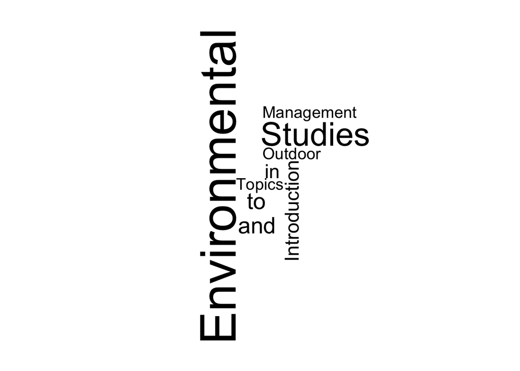

```r
library( wordcloud )
wordcloud( words = tdm$word,
           freq = tdm$freq )
```

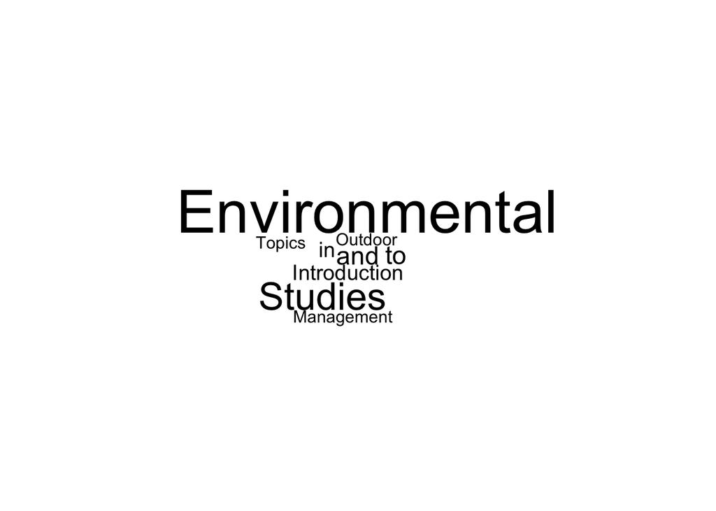

```r
wordcloud( words = tdm$word,
           freq = tdm$freq,
           scale=c(3.5,0.25) )
```

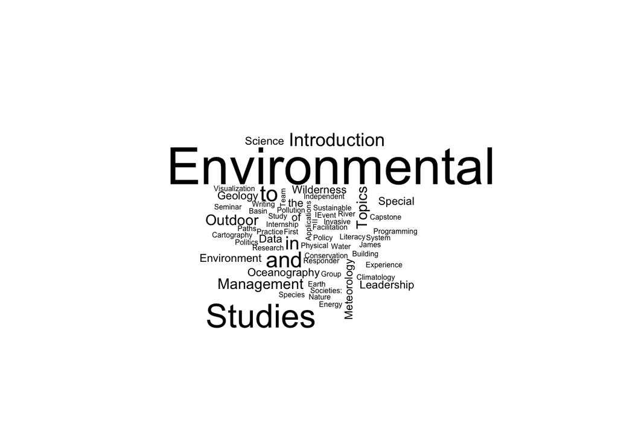

```r
wordcloud( words = tdm$word,
           freq = tdm$freq,
           scale=c(3.5,0.25),
           min.freq = 1 )
```

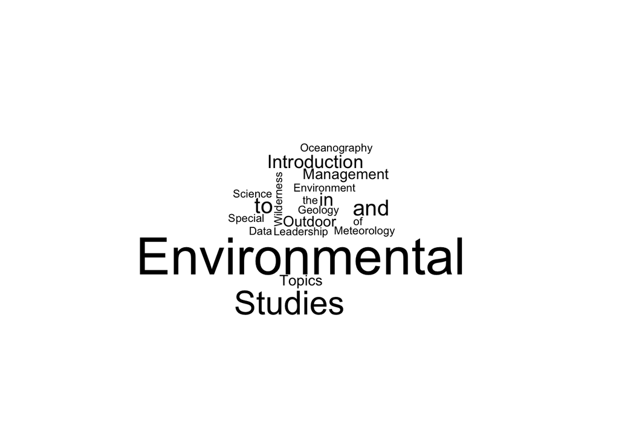

```r
wordcloud( words = tdm$word,
           freq = tdm$freq,
           scale=c(3.5,0.25),
           min.freq = 2 )
```

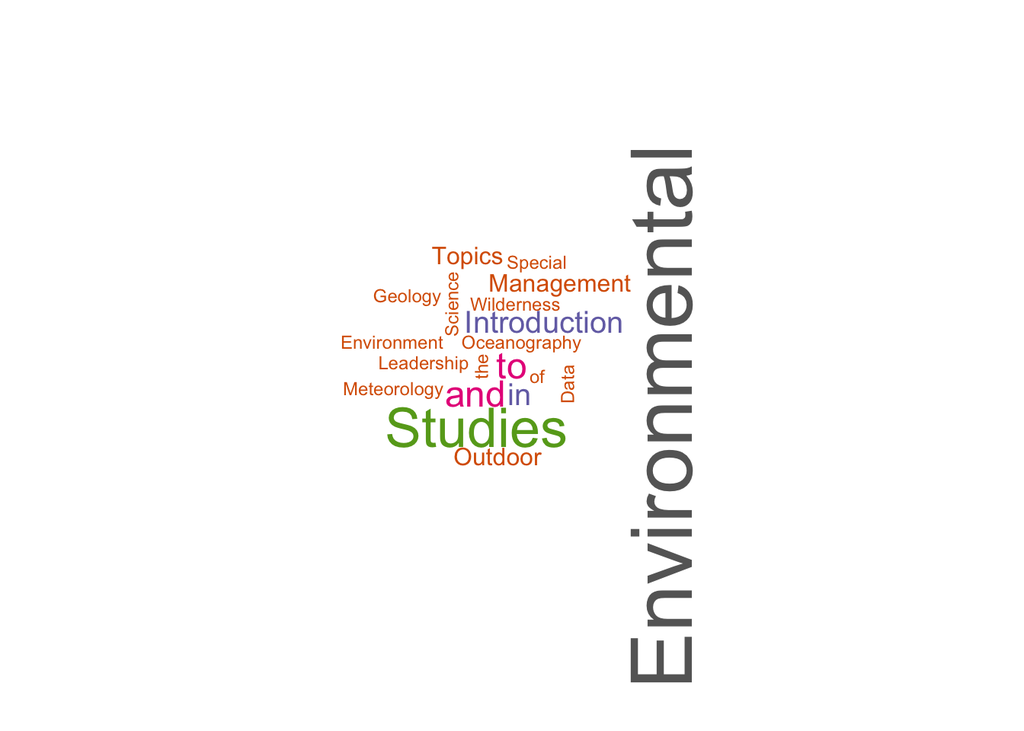

```r
wordcloud( words = tdm$word,
           freq = tdm$freq,
           scale=c(3.5,0.25),
           min.freq = 2,
           colors = brewer.pal(8,"Dark2"))
```

```r
library( wordcloud2 )
wordcloud2(data = tdm)
```

[interactive chart not shown]